# Examples of STARX

This R package provides a flexible framework to estimate spatiotemporal autoregressive model with exogenous variables. In the following, we are going to show how to use our package to fit STAR models with exogenous variables. To use our package, one should install the following packages

```r
rm(list = ls())
library(Triangulation)
library(TPST)
library(STARX)
```

# STAR-PLVCM

In this part, we consider the spatiotemporal autoregressive partially linear varying coefficient models (STAR-PLVCM).

## Data generating

We first generate the data by

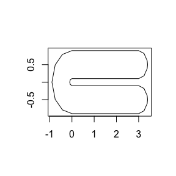

```r
# set up
nS <- 100
nT <- 30
sigma <- 0.5
alpha <- 0.5

# boundary of space and time
data("horseshoe.b")
plot(horseshoe.b$V1, horseshoe.b$V2, type = "l", xlab = '', ylab = '')
```

```r
time.bound <- c(0, 1)

# generate simulation data
data.simu <- simu.data.generating(nS, nT, sigma, alpha, k = 10, horseshoe.b)
```

## Model Estimation

Then, we set the parameters in TPST.

[figure not shown]

```r
# tensor product spline degree and order
N <- 4 # Number of interior knots.
d <- 2 # Degree of bivariate spline.
r <- 1 # smoothness of bivariate spline.
rho <- 3 # order of univariate spline.

# load triangulation
data("Tr.hs.1")
data("V.hs.1")
TriPlot(V.hs.1, Tr.hs.1)
```

```r
# knots
probs <- seq(time.bound[1], time.bound[2], length.out = N + 2)
time.knots <- quantile(data.simu$location[, 3], probs = probs)[-c(1, N + 2)]

time.knots
```

```
##       20%       40%       60%       80%
## 0.2266667 0.4200000 0.6133333 0.8066667
```

We use star.fit to fit the model.

```r
# fit model -------------------------------------------------------------
Lambda1 <- exp(seq(log(0.001), log(1000), length.out = 5))
Lambda2 <- exp(seq(log(0.001), log(1000), length.out = 5))
Lambda <- expand.grid(Lambda1, Lambda2)
#
# mfit1 <- star.fit(data = data.simu, Lambda, V.hs.1, Tr.hs.1, d, r,
#                   time.knots, rho, time.bound, return.se = TRUE)
# save(mfit1, file = "/Users/shanyu/Dropbox/Research/STVCM2018/Packages/STARX/vignettesmfit1.rda")
```

## Results

The estimators of STAR-PLVCM are the following.

```r
load("/Users/shanyu/Dropbox/Research/STVCM2018/Packages/STARX/vignettesmfit1.rda")
# Estimated parameters in STAR-PLVCM.
c(mfit1$alpha.hat, mfit1$mse, mfit1$theta.hat[1:mfit1$n.Z])
```

```
## [1]  0.5104688  0.2530325  4.8758916  0.9954596 -0.9947850
```

```r
# Estimated standard deviation
mfit1$se.eta
```

```
## [1] 0.018023536 0.006535487 0.179374619 0.009205960 0.009450905
```

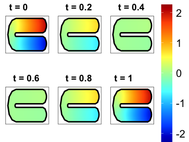

```r
# sequence of spatial plots of estimated coefficient functions.
ngrid.x <- 40
ngrid.y <- 20
ngrid.t <- 6

fitted.beta <- beta.func.plot(fitted = mfit1, ngrid.x, ngrid.y, ngrid.t,
               boundary = horseshoe.b, boundary.t = time.bound,
               beta.true.ind = TRUE, beta.true = list(beta1.func), coord.ratio = 2)

fitted.beta$beta.true.all[[1]]
```

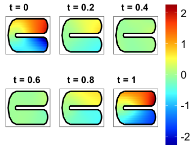

```r
fitted.beta$beta.est.all[[1]]
```

The accuracy of estimators are evaluated by

```r
# model evaluation ------------------------------------------------------
ngrid.x <- 40
ngrid.y <- 20
ngrid.t <- 6

# the regression points
xx <- seq(-0.89, 3.39, length.out = ngrid.x)
yy <- seq(-0.89, 0.89, length.out = ngrid.y)
ss <- expand.grid(xx, yy)
tt <- (0:(ngrid.t - 1)) / (ngrid.t - 1)

data.grid <- data.frame(
  x = rep(ss[, 1], ngrid.t), y = rep(ss[, 2], ngrid.t),
  t = rep(tt, each = dim(ss)[1]), z1 = 1, x1 = 1, x2 = 1
)

eta.true <- c(5, 1, -1)
beta.true <- list(beta1.func)
alpha.true <- 0.5

result <- eval.star(fitted = mfit1, beta.true, eta.true,
                    alpha.true, data.grid)

# MSE of alpha
result$mse.alpha
```

```
## [1] 0.0001095947
```

```r
# MSE of eta
result$mse.eta
```

```
## [1] 1.540291e-02 2.061506e-05 2.719632e-05
```

```r
# MISE of coefficient functions
result$mise.beta
```

```
## [1] 0.02158701
```

# STAR-LM

Our package can also be used to fit the spatiotemporal autoregressive linear coefficient models (STAR-LM). Let the argument X be *NULL*, *star.fit* automatically fit a STAR-LM.

```r
data.simu.lm <- data.simu
data.simu.lm$X <- NULL

mfit2 <- star.fit(data = data.simu.lm, Lambda, V.hs.1, Tr.hs.1, d, r,
                  time.knots, rho, time.bound, return.se = TRUE)
```

## Results

```r
# Estimated parameters in STAR-PLVCM.
c(mfit2$alpha.hat, mfit2$mse, mfit2$theta.hat[1:mfit2$n.Z])
```

```
##                                W        Wz1        Wz2
##  0.4911328  0.5155324  5.0966187  0.9907314 -0.9855993
```

```r
# Estimated standard deviation
mfit2$se.eta
```

```
## [1] 0.02603684 0.01330847 0.26104084 0.01301526 0.01284151
```

# STAR-VCM

Our package can also be used to fit the spatiotemporal autoregressive varying coefficient models (STAR-VCM). Similar to STAR-LM, let the argument Z be *NULL*, *star.fit* automatically fit a STAR-VCM.

```r
data.simu.vcm <- data.simu
data.simu.vcm$Z <- NULL

# mfit3 <- star.fit(data = data.simu.vcm, Lambda, V.hs.1, Tr.hs.1, d, r,
#                   time.knots, rho, time.bound, return.se = TRUE)
#
# save(mfit3, file = "/Users/shanyu/Dropbox/Research/STVCM2018/Packages/STARX/mfit3.rda")
```

## Results

```r
load("/Users/shanyu/Dropbox/Research/STVCM2018/Packages/STARX/mfit3.rda")
# Estimated parameters in STAR-PLVCM.
c(mfit3$alpha.hat, mfit3$mse, mfit3$theta.hat[1:mfit3$n.Z])
```

```
## [1] 0.3886523 2.0944652 6.0343094
```

```r
# Estimated standard deviation
mfit3$se.eta
```

```
## [1] 0.05194092 0.05297816 0.51406351
```

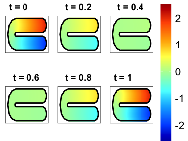

```r
# sequence of spatial plots of estimated coefficient functions.
ngrid.x <- 40
ngrid.y <- 20
ngrid.t <- 6

fitted.beta3 <- beta.func.plot(fitted = mfit3, ngrid.x, ngrid.y, ngrid.t,
               boundary = horseshoe.b, boundary.t = time.bound,
               beta.true.ind = TRUE, beta.true = list(beta1.func), coord.ratio = 2)

fitted.beta3$beta.true.all[[1]]
```

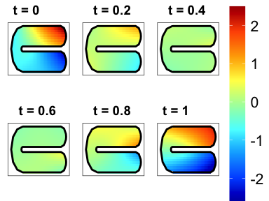

```r
fitted.beta3$beta.est.all[[1]]
```

# STVCM

Our package can also be used to fit partially linear spatiotemporally varying coefficient model.

```r
data.simu.stvcm <- data.simu
data.simu.stvcm$W <- NULL
mfit4 <- stvcm.fit(data = data.simu.stvcm, Lambda, V.hs.1, Tr.hs.1, d, r,
                  time.knots, rho, time.bound, return.se = TRUE)
```

## Results

```r
# Estimated parameters in STAR-PLVCM.
c(mfit4$theta.hat[1:mfit4$n.Z])
```

```
## [1] 10.0086743  1.0022261 -0.9974966
```

```r
# Estimated standard deviation
mfit4$se.eta
```

```
## [1] 0.010060860 0.009981634 0.009868535
```

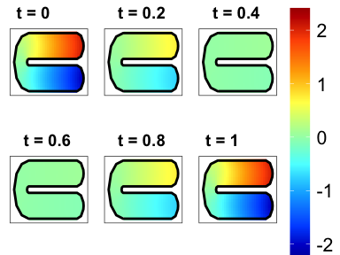

```r
# sequence of spatial plots of estimated coefficient functions.
ngrid.x <- 40
ngrid.y <- 20
ngrid.t <- 6

fitted.beta4 <- beta.func.plot(fitted = mfit4, ngrid.x, ngrid.y, ngrid.t,
               boundary = horseshoe.b, boundary.t = time.bound,
               beta.true.ind = TRUE, beta.true = list(beta1.func), coord.ratio = 2)

fitted.beta4$beta.true.all[[1]]
```

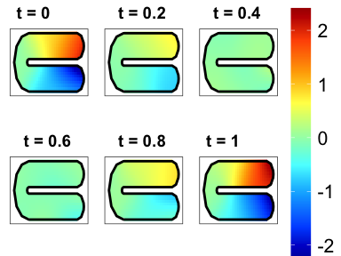

```r
fitted.beta4$beta.est.all[[1]]
```